# Data_exploration_assignment

WanchiPeng

2022-07-24

## Libraries: loading all the libraries

```r
library(tidyverse)
library(lubridate)
```

```r
library(ggplot2)
library(ggforce)
library(zoom)
library(fixest)
library(vtable)
```

# Use list.files(), read_csv and bind_rows() to read and combine as data frame.

```r
list_filenames <- list.files(path="../data/", pattern="trends_up_to_", all.files=FALSE, full.names=TRUE)
df_list <- map(list_filenames, read_csv)
df <- bind_rows(df_list)
```

# Read CollegeScorecardDatadictionary, id_name_link and MostRecentCohortsScorecardElements files.

```r
CollegeScorecardDatadictionary <- read_csv('../data/CollegeScorecardDatadictionary-09-08-2015.csv')
id_name_link <- read_csv('../data/id_name_link.csv')
Scorecard <- read_csv('../data/Most+Recent+Cohorts+(Scorecard+Elements).csv')
```

# As you can see below, we are just getting estimate scale from all 3 data sources.

# Google trend dataset contains 1.5M records while scoredcard daatset contains ~7.8k records while id_name_link dataset contains ~3.6k records. This tell us that after inner joins + filtering certain conditions + aggregating google trends, our final dataframe would have less than ~3.6k unique college records.

```r
nrow(df)
```

```
## [1] 1593740
```

```r
nrow(id_name_link)
```

```
## [1] 3595
```

```r
nrow(Scorecard)
```

```
## [1] 7804
```

# Here, as a first step after data import, we will aggregate the Google Trends data.

# Approach : Get the first ten characters from monthorweek, get the month from monthorweek and turn both results into date

```r
df <- df %>% mutate(date = str_sub(monthorweek, 1, 10)) %>% mutate(date_usable = ymd(date)) %>% select(-date) %>% mutate(month_of_record = floor_date(date_usable, 'month'))
```

# As the google trends data index is not an absolute index or using same calibration process across different google keywords/college names it maps to, we will need to normalize the data to have them at standardize scale.

# To standardize index, we subtract mean and divide by standard deviation.

# We also group by records to schoolname and month of the record so (schoolname,month) level summarization.

```r
normalized_df <- df %>% drop_na(index) %>% group_by(schname,keyword) %>% mutate(index_standardized = (index - mean(index))/sd(index)) %>% group_by(schname, month_of_record) %>% summarize(mean_index_standardized = mean(index_standardized))
```

# PREDDEG column shows predominant degrees awarded by colleges so we filter only the schools that predominantly grant bachelor’s degree.

```r
Scorecard <- Scorecard %>% filter(PREDDEG == 3)
```

# To analyze earnings reported for alumni of these different colleges, we use “md_earn_wne_p10-REPORTED-EARNINGS” column from Scorecard dataset as that displays median earning reported after 10 years of enrollement for a particular college.

# In Scorecard data, there are some colleges for which earnings column is either “PrivacySuppressed” or “NULL”. As imported dataset column was “md_earn_wne_p10-REPORTED-EARNINGS” classified as char, we see “NULL” string instead of NA.

# For both string terms “PrivacySuppressed” or “NULL”, we can impute them with 0/mean value or we can just drop them as data isn’t available.

# I tried with 0 and mean value imputation but eventually, I decided to drop them as that was the best result for my executions.

```r
sum(Scorecard$'md_earn_wne_p10-REPORTED-EARNINGS' == "PrivacySuppressed")
```

```
## [1] 127
```

```r
sum(Scorecard$'md_earn_wne_p10-REPORTED-EARNINGS' == "NULL")
```

```
## [1] 133
```

```r
sum(is.na(Scorecard$'md_earn_wne_p10-REPORTED-EARNINGS'))
```

```
## [1] 0
```

```r
nrow(Scorecard)
```

```
## [1] 2133
```

```r
Scorecard<-Scorecard[!(Scorecard$'md_earn_wne_p10-REPORTED-EARNINGS' == "NULL" | Scorecard$'md_earn_wne_p10-REPORTED-EARNINGS' == "PrivacySuppressed" ),]
nrow(Scorecard)
```

```
## [1] 1873
```

```r
##Scorecard$'md_earn_wne_p10-REPORTED-EARNINGS'[Scorecard$'md_earn_wne_p10-REPORTED-EARNINGS' == "PrivacySuppressed"] <- 0
##Scorecard$'md_earn_wne_p10-REPORTED-EARNINGS'[Scorecard$'md_earn_wne_p10-REPORTED-EARNINGS' == "NULL"] <- 0
```

# As I mentioned above, the default import classification of “md_earn_wne_p10-REPORTED-EARNINGS” is char, I created a new column by typecasting it to numeric data type.

```r
Scorecard<-transform(Scorecard, earnings = as.numeric(Scorecard$'md_earn_wne_p10-REPORTED-EARNINGS'))
```

## I also tried to defines some absolute values (low earning : below 25k and high earning : above 75k) to define thresholds, but evetually, quntile 29 and quantile 79 worked best.

```r
max_earning <- max(Scorecard$earnings)
min_earning <- min(Scorecard$earnings)
mean_earning <- mean(Scorecard$earnings)
quantile(Scorecard$earnings, probs = c(0.1, 0.25, 0.29, 0.75, 0.79, 0.9, 1))
```

```
##    10%    25%    29%    75%    79%    90%   100%
##  29700  35100  36100  47600  49900  54300 166200
```

```r
earning_29 <- quantile(Scorecard$earnings, probs = c(0.29))
earning_79 <-quantile(Scorecard$earnings, probs = c(0.79))
```

# Drop those schools from id_name link data which are sharing the same name.

```r
length(unique(id_name_link$schname))
```

```
## [1] 3555
```

```r
id_name_link <- id_name_link %>% group_by(schname) %>% mutate(n = n()) %>% filter(n==1) %>% select(-n)
nrow(id_name_link)
```

```
## [1] 3523
```

# Join google trends data to id_name_link by school name and then id_name_link table to Scorecard data by unitid. # Also, filter only rows where earnings are less than 29th percentile or greater than 79th percentile.

```r
final_df <- normalized_df %>% inner_join(id_name_link, 'schname') %>% inner_join(Scorecard, by = c("unitid" = "UNITID")) %>% select(-c(OPEID, opeid6, INSTNM)) %>% filter(earnings >= earning_79 | earnings <= earning_29) %>%
  mutate(earning_category = case_when(earnings >= earning_79 ~ '1', earnings <= earning_29 ~ '0')) %>%
  mutate(scorecard_implemented = case_when(month_of_record >= '2015-09-01' ~ '1', TRUE ~ '0'))
final_df <- final_df%>%mutate(part_of_the_year = case_when(month(month_of_record) <= 7 ~ '0', month(month_of_record) >7 ~ '1'))
final_df <- final_df%>%mutate(year_of_record = year(month_of_record))
final_df$year_info <- paste(final_df$part_of_the_year,"-",final_df$year_of_record)
```

# Trying to see how the data looks like in graph-Explore with month_of_record and mean_index_standardized

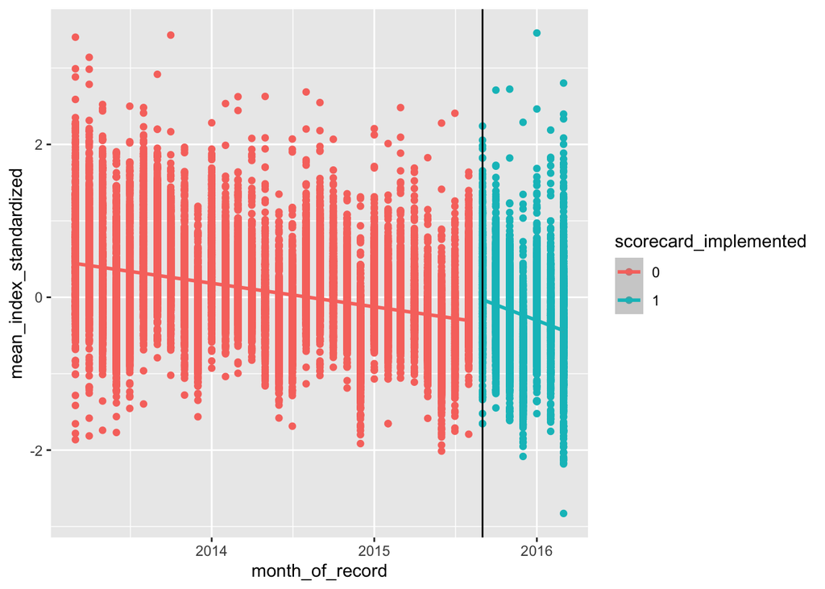

```r
ggplot(final_df, aes(x=month_of_record, y=mean_index_standardized,col=scorecard_implemented)) + geom_point() + geom_smooth(method = 'lm') + geom_vline(xintercept = as.Date("2015-09-01"))
```

```r
m3 <- feols(mean_index_standardized~month_of_record, data = final_df)
```

# Split out those schools considered having high-earning and low-earning, group by month.

# In this assignment I consider high-earning as 79th percentile of earning and low-earning as 29th percentile of earning.

```r
high_earning_df <- final_df %>% filter(earnings >= earning_79)
low_earning_df <- final_df %>% filter(earnings <= earning_29)

length(unique(high_earning_df$schname))
```

```
## [1] 389
```

```r
length(unique(low_earning_df$schname))
```

```
## [1] 501
```

# Run regression model and plot the month_of_record and mean of the standardized index to see the relationship

# From the regression result and graph for both high-earning dataframe and low-earning dataframe we can see there is negative relationship between the month and search interest.

# As you can see in graph below, search trend can also be seen as a function of time. Regardless of scorecards implemented, every Jan-July month, search trend overall decreases for all high earning and all learning colleges on average and the jumps back in Aug and decreases again till December. This might be the correlation between when people apply for colleges or when term starts, students will check more information boosting search trend.

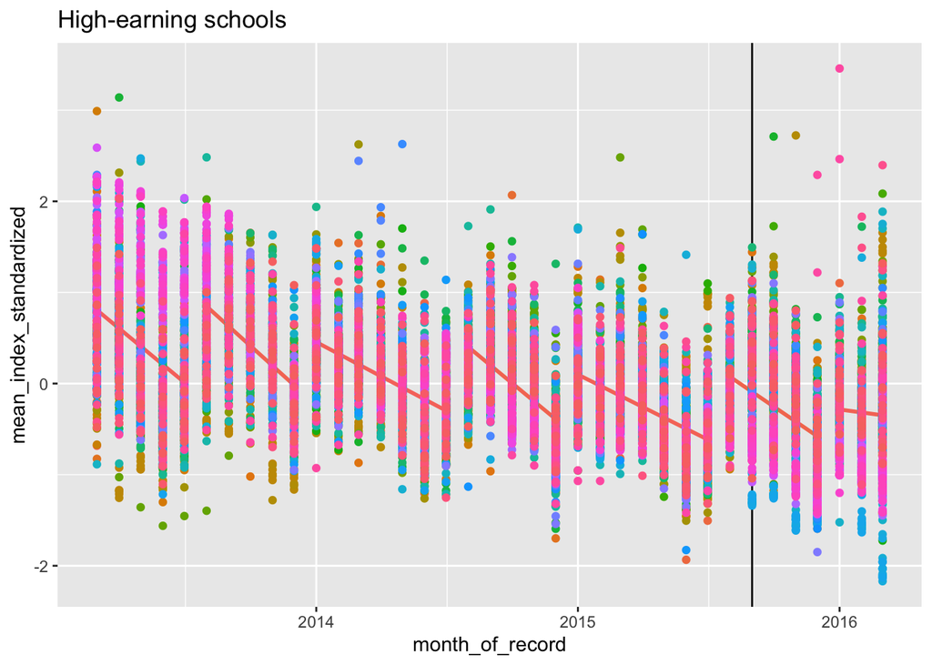

```r
high_earning_df <- final_df %>% filter(earnings >= earning_79)
ggplot(high_earning_df, aes(x=month_of_record, y=mean_index_standardized, col=year_info)) + geom_smooth(method = 'lm',se=FALSE) + geom_vline(xintercept = as.Date("2015-09-01"))+ ggtitle("High-earning schools") + geom_point(aes(color = schname)) + theme(legend.position="none")
```

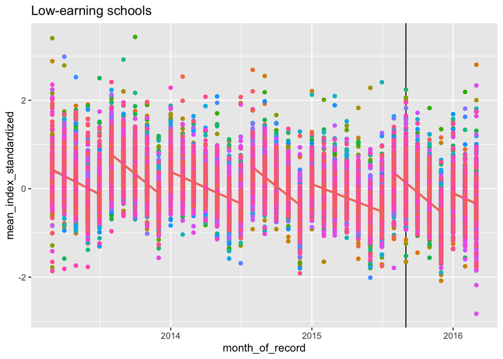

```r
m1 <- feols(mean_index_standardized~month_of_record, data = high_earning_df)

low_earning_df <- final_df %>% filter(earnings <= earning_29)
ggplot(low_earning_df, aes(x=month_of_record, y=mean_index_standardized, col=year_info)) + geom_smooth(method = 'lm') + geom_vline(xintercept = as.Date("2015-09-01"))+ ggtitle("Low-earning schools") + geom_point(aes(color = schname)) + theme(legend.position="none")
```

```r
m2 <- feols(mean_index_standardized~month_of_record, data = low_earning_df)
etable(m1, m2)
```

```
##                                      m1                      m2
## Dependent Var.: mean_index_standardized mean_index_standardized
##
## (Intercept)           14.79*** (0.2335)       9.081*** (0.2050)
## month_of_record    -0.0009*** (1.43e-5)    -0.0006*** (1.26e-5)
## _______________ _______________________ _______________________
## S.E. type                           IID                     IID
## Observations                     14,267                  18,296
## R2                              0.21936                 0.09685
## Adj. R2                         0.21930                 0.09680
## ---
## Signif. codes: 0 '***' 0.001 '**' 0.01 '*' 0.05 '.' 0.1 ' ' 1
```

#Filter and keep only earnings categorized as high and low earnings in the dataframe #Run regression model and plot the month_of_record and mean of the standardized index to see the relationship #From the regression result and graph we can see there is negative relationship between the month and search interest

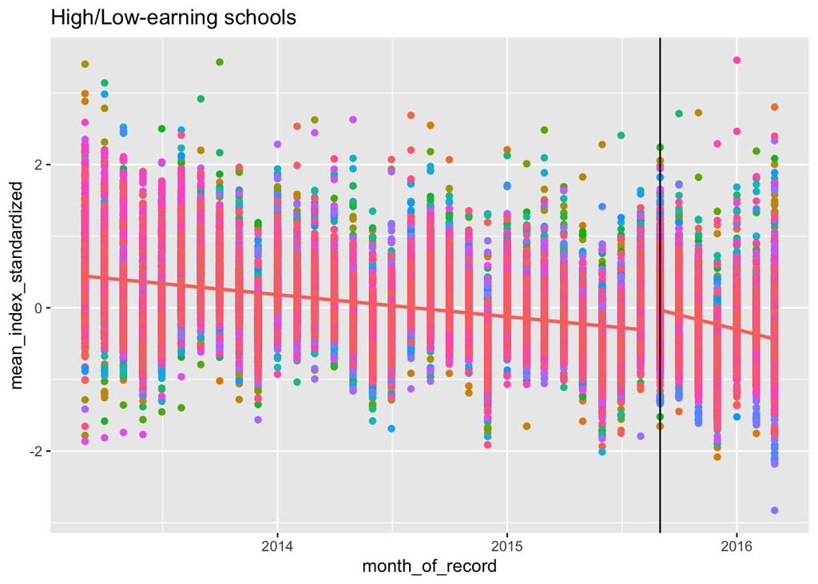

```r
final_df_high_low <- final_df %>% filter(earnings >= earning_79 | earnings <= earning_29)
ggplot(final_df_high_low, aes(x=month_of_record, y=mean_index_standardized, col=scorecard_implemented)) + geom_point(aes(color = schname)) + theme(legend.position="none")  + geom_smooth(method = 'lm') + geom_vline(xintercept = as.Date("2015-09-01"))+ ggtitle("High/Low-earning schools")
```

```r
m4 <- feols(mean_index_standardized~month_of_record, data = final_df_high_low)
etable(m3, m4)
```

```
##                                      m3                      m4
## Dependent Var.: mean_index_standardized mean_index_standardized
##
## (Intercept)           11.60*** (0.1548)       11.60*** (0.1548)
## month_of_record    -0.0007*** (9.49e-6)    -0.0007*** (9.49e-6)
## _______________ _______________________ _______________________
## S.E. type                           IID                     IID
## Observations                     32,563                  32,563
## R2                              0.14682                 0.14682
## Adj. R2                         0.14679                 0.14679
## ---
## Signif. codes: 0 '***' 0.001 '**' 0.01 '*' 0.05 '.' 0.1 ' ' 1
```

#Plot high_earning_df and low_earning_df in same plot to see how data distributed #From the graph we can see that after Sep, 2015 there are some higher searching interests in high-earning schools(higher than before Sep, 2015), #and at the right bottom corner we can see one point is even lower than left bottom corner(Before Sep, 2015 is lower than after Sep, 2015)

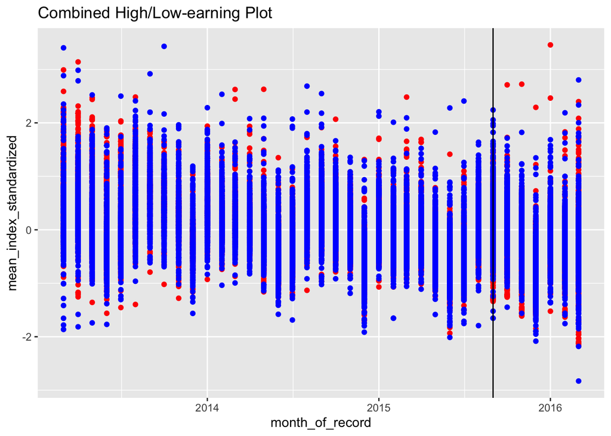

```r
ggplot(NULL, aes(x=month_of_record, y=mean_index_standardized)) +
  geom_point(data = high_earning_df, col = "red") +
  geom_point(data = low_earning_df, col = "blue") +
  geom_vline(xintercept = as.Date("2015-09-01"))+
  ggtitle("Combined High/Low-earning Plot")
```

#To check total school numbers in each dataframe

```r
length(unique(final_df$schname))
```

```
## [1] 890
```

```r
length(unique(high_earning_df$schname))
```

```
## [1] 389
```

```r
length(unique(low_earning_df$schname))
```

```
## [1] 501
```

#To look at the variable in final_df

```r
vtable(final_df)
```

final_df

| Name | Class | Values |
| --- | --- | --- |
| schname | character |  |
| month_of_record | Date | Time: 2013-03-01 to 2016-03-01 |
| mean_index_standardized | numeric | Num: -2.829 to 3.458 |
| unitid | numeric | Num: 100654 to 474979 |
| opeid | numeric | Num: 100200 to 82098821 |
| CITY | character |  |
| STABBR | character |  |
| INSTURL | character |  |
| NPCURL | character |  |
| HCM2 | numeric | Num: 0 to 1 |
| PREDDEG | numeric | Num: 3 to 3 |
| CONTROL | numeric | Num: 1 to 3 |
| LOCALE | character |  |
| HBCU | character |  |
| PBI | character |  |
| ANNHI | character |  |
| TRIBAL | character |  |
| AANAPII | character |  |
| HSI | character |  |
| NANTI | character |  |
| MENONLY | character |  |
| WOMENONLY | character |  |
| RELAFFIL | character |  |
| SATVR25 | character |  |
| SATVR75 | character |  |
| SATMT25 | character |  |
| SATMT75 | character |  |
| SATWR25 | character |  |
| SATWR75 | character |  |
| SATVRMID | character |  |

[output cut: 99 more lines]

#Run the code in the chunk below to look at the distribution of earnings:

```r
#ggplot(final_df, aes(x = earnings)) + geom_density()
```

```r
model1 <- feols(mean_index_standardized~log(earnings), data = final_df)
etable(model1)
```

```
##                                  model1
## Dependent Var.: mean_index_standardized
##
## (Intercept)            -0.0939 (0.0980)
## log(earnings)           0.0095 (0.0092)
## _______________ _______________________
## S.E. type                           IID
## Observations                     32,563
## R2                              3.23e-5
## Adj. R2                         1.57e-6
## ---
## Signif. codes: 0 '***' 0.001 '**' 0.01 '*' 0.05 '.' 0.1 ' ' 1
```

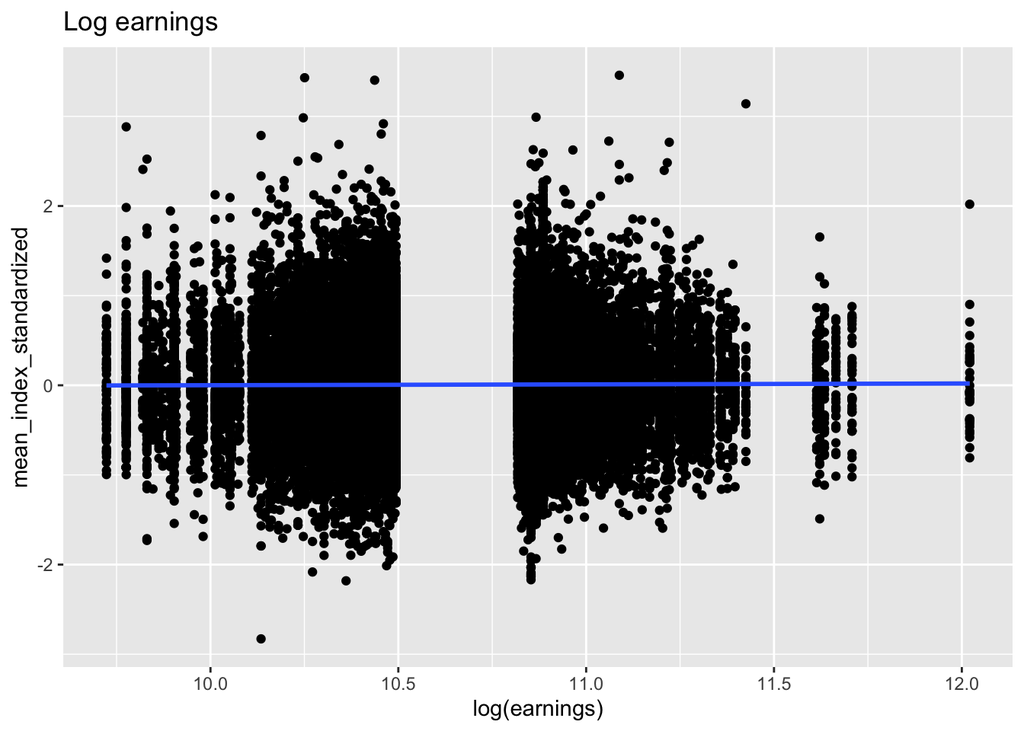

```r
ggplot(final_df, aes(x=log(earnings), y= mean_index_standardized)) + geom_point() + geom_smooth(method = 'lm')+ ggtitle("Log earnings")
```

#Forming the regression formula with Y(dependent variable) as mean of standardized index and X(independent variable) as whether implemented scorecard or not(binary variable) #From the regression result we can see that after implementing scorecard, the search interest actually decreased.

```r
model2 <- feols(mean_index_standardized~scorecard_implemented, data = final_df)
etable(model2)
```

```
##                                         model2
## Dependent Var.:        mean_index_standardized
##
## (Intercept)                 0.0636*** (0.0036)
## scorecard_implemented1     -0.2982*** (0.0082)
## ______________________ _______________________
## S.E. type                                  IID
## Observations                            32,563
## R2                                     0.03876
## Adj. R2                                0.03873
## ---
## Signif. codes: 0 '***' 0.001 '**' 0.01 '*' 0.05 '.' 0.1 ' ' 1
```

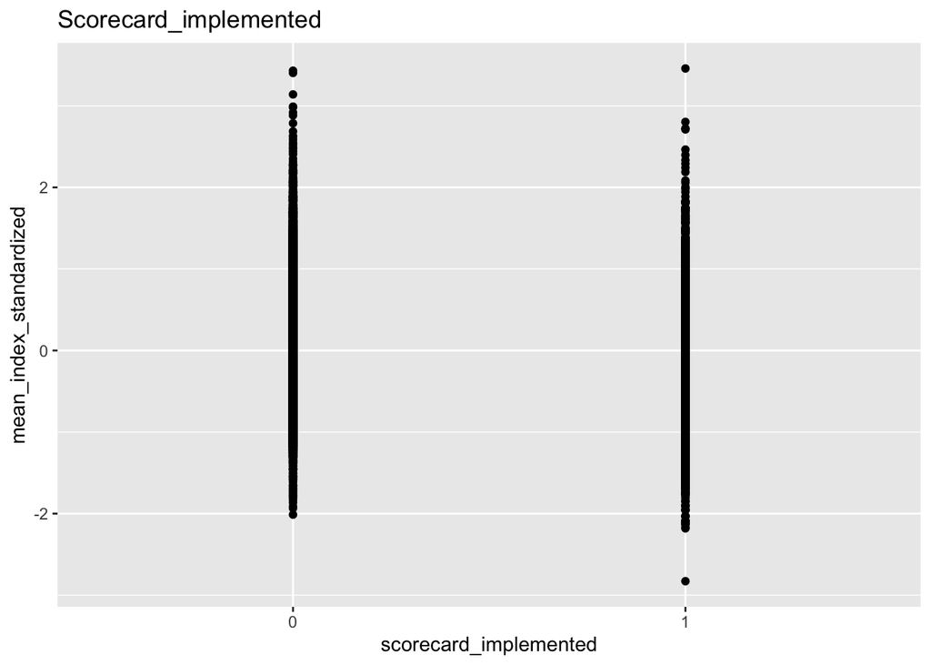

```r
ggplot(final_df, aes(x=scorecard_implemented, y= mean_index_standardized)) + geom_point() + geom_smooth(method = 'lm') + ggtitle("Scorecard_implemented")
```

```r
model3 <- feols(mean_index_standardized~scorecard_implemented + earning_category, data = final_df)
etable(model3)
```

```
##                                         model3
## Dependent Var.:        mean_index_standardized
##
## (Intercept)                 0.0599*** (0.0046)
## scorecard_implemented1     -0.2982*** (0.0082)
## earning_category1              0.0084 (0.0065)
## ______________________ _______________________
## S.E. type                                  IID
## Observations                            32,563
## R2                                     0.03881
## Adj. R2                                0.03875
## ---
## Signif. codes: 0 '***' 0.001 '**' 0.01 '*' 0.05 '.' 0.1 ' ' 1
```

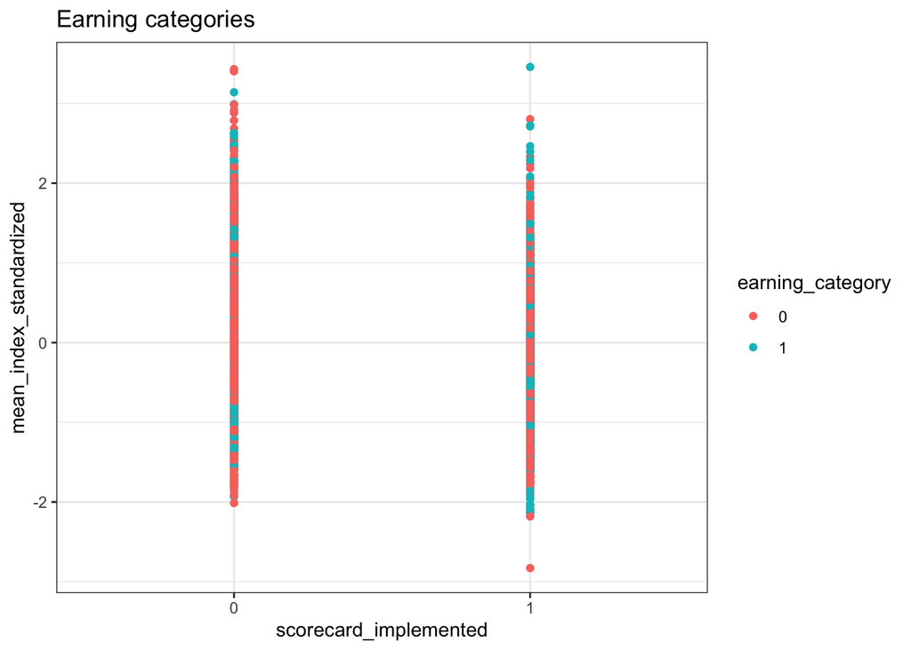

```r
ggplot(data=final_df, mapping = aes(x=scorecard_implemented, y= mean_index_standardized)) + geom_point(aes(color = earning_category)) + theme_bw() + ggtitle("Earning categories")
```

```r
model4 <- feols(mean_index_standardized~scorecard_implemented + earning_category + HCM2 + CONTROL + CURROPER, data = final_df)
etable(model4)
```

```
##                                         model4
## Dependent Var.:        mean_index_standardized
##
## (Intercept)                  0.0702** (0.0269)
## scorecard_implemented1     -0.2982*** (0.0082)
## earning_category1              0.0079 (0.0066)
## HCM2                          -0.0091 (0.0482)
## CONTROL                        0.0007 (0.0051)
## CURROPER                      -0.0116 (0.0234)
## ______________________ _______________________
## S.E. type                                  IID
## Observations                            32,563
## R2                                     0.03882
## Adj. R2                                0.03867
## ---
## Signif. codes: 0 '***' 0.001 '**' 0.01 '*' 0.05 '.' 0.1 ' ' 1
```

```r
model5 <- feols(mean_index_standardized~scorecard_implemented*earning_category, data = final_df)
etable(model5)
```

```
##                                                             model5
## Dependent Var.:                            mean_index_standardized
##
## (Intercept)                                     0.0471*** (0.0048)
## scorecard_implemented1                         -0.2311*** (0.0110)
## earning_category1                               0.0377*** (0.0072)
## scorecard_implemented1 x earning_category1     -0.1534*** (0.0166)
## ________________________________________   _______________________
## S.E. type                                                      IID
## Observations                                                32,563
## R2                                                         0.04133
## Adj. R2                                                    0.04124
## ---
## Signif. codes: 0 '***' 0.001 '**' 0.01 '*' 0.05 '.' 0.1 ' ' 1
```

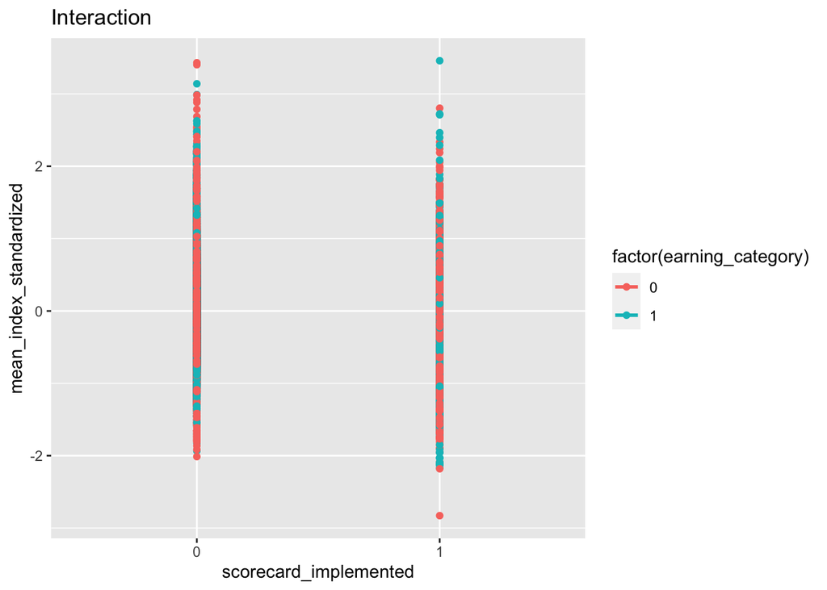

```r
ggplot(final_df,aes(y=mean_index_standardized,x=scorecard_implemented,color=factor(earning_category)))+geom_point()+stat_smooth(method="lm",se=FALSE) + ggtitle("Interaction")
```

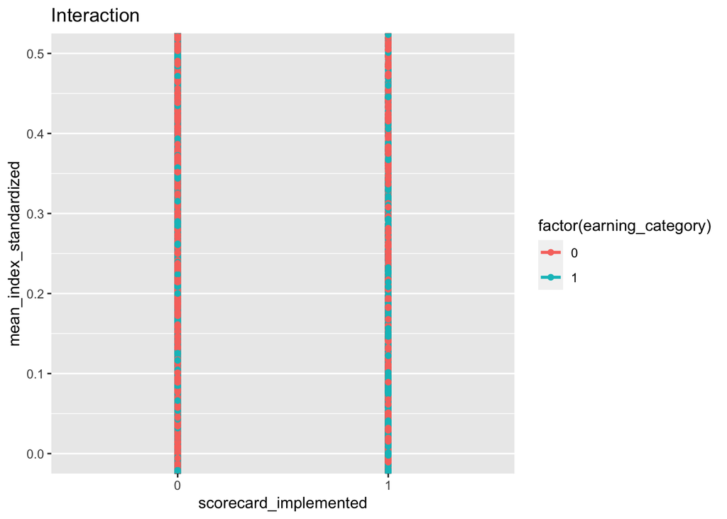

```r
ggplot(final_df,aes(y=mean_index_standardized,x=scorecard_implemented,color=factor(earning_category)))+geom_point()+stat_smooth(method="lm",se=FALSE) + ggtitle("Interaction") + coord_cartesian(ylim = c(0,0.5))
```

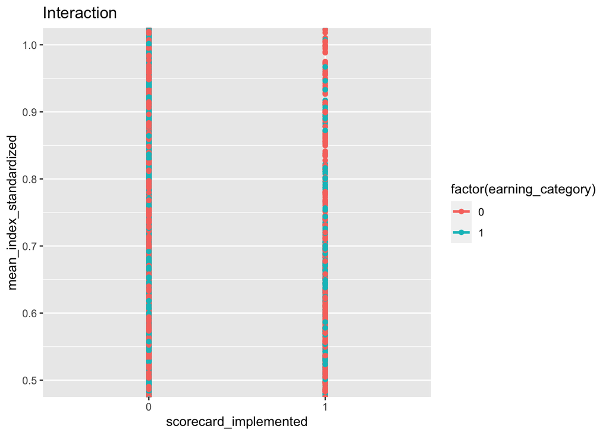

```r
ggplot(final_df,aes(y=mean_index_standardized,x=scorecard_implemented,color=factor(earning_category)))+geom_point()+stat_smooth(method="lm",se=FALSE) + ggtitle("Interaction") + coord_cartesian(ylim = c(0.5,1))
```

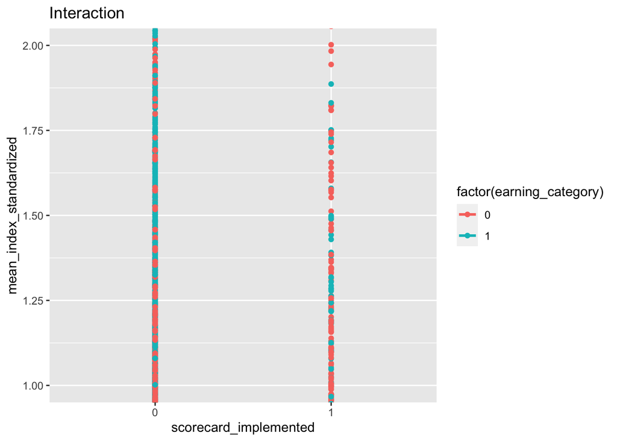

```r
ggplot(final_df,aes(y=mean_index_standardized,x=scorecard_implemented,color=factor(earning_category)))+geom_point()+stat_smooth(method="lm",se=FALSE) + ggtitle("Interaction") + coord_cartesian(ylim = c(1,2))
```

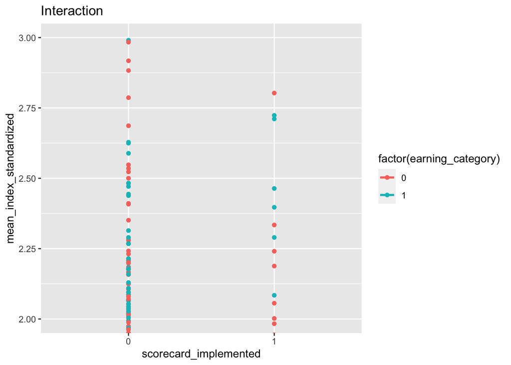

```r
ggplot(final_df,aes(y=mean_index_standardized,x=scorecard_implemented,color=factor(earning_category)))+geom_point()+stat_smooth(method="lm",se=FALSE) + ggtitle("Interaction") + coord_cartesian(ylim = c(2,3))
```

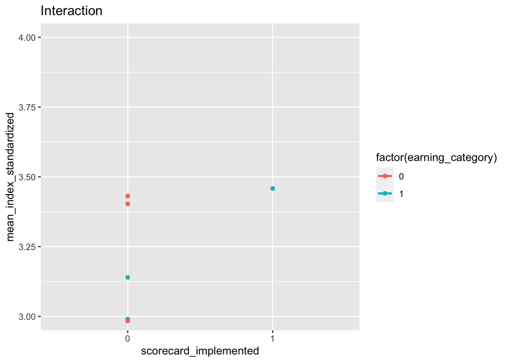

```r
ggplot(final_df,aes(y=mean_index_standardized,x=scorecard_implemented,color=factor(earning_category)))+geom_point()+stat_smooth(method="lm",se=FALSE) + ggtitle("Interaction") + coord_cartesian(ylim = c(3,4))
```

[figure not shown]

```r
ggplot(final_df,aes(y=mean_index_standardized,x=scorecard_implemented,color=factor(earning_category)))+geom_point()+stat_smooth(method="lm",se=FALSE) + ggtitle("Interaction") + coord_cartesian(ylim = c(4,5))
```

#To see all of regression results together

```r
etable(model1,model2,model3,model4,model5)
```

```
##                                                             model1
## Dependent Var.:                            mean_index_standardized
##
## (Intercept)                                       -0.0939 (0.0980)
## log(earnings)                                      0.0095 (0.0092)
## scorecard_implemented1
## earning_category1
## HCM2
## CONTROL
## CURROPER
## scorecard_implemented1 x earning_category1
## ________________________________________   _______________________
## S.E. type                                                      IID
## Observations                                                32,563
## R2                                                         3.23e-5
## Adj. R2                                                    1.57e-6
##
##                                                             model2
## Dependent Var.:                            mean_index_standardized
##
## (Intercept)                                     0.0636*** (0.0036)
## log(earnings)
## scorecard_implemented1                         -0.2982*** (0.0082)
## earning_category1
## HCM2
## CONTROL
## CURROPER
## scorecard_implemented1 x earning_category1
## ________________________________________   _______________________
## S.E. type                                                      IID
## Observations                                                32,563
## R2                                                         0.03876
## Adj. R2                                                    0.03873
##
##                                                             model3
## Dependent Var.:                            mean_index_standardized
##
## (Intercept)                                     0.0599*** (0.0046)
## log(earnings)
## scorecard_implemented1                         -0.2982*** (0.0082)
```

[output cut: 31 more lines]

```
## (Intercept)                                     0.0471*** (0.0048)
## log(earnings)
## scorecard_implemented1                         -0.2311*** (0.0110)
## earning_category1                               0.0377*** (0.0072)
## HCM2
## CONTROL
## CURROPER
## scorecard_implemented1 x earning_category1     -0.1534*** (0.0166)
## ________________________________________   _______________________
## S.E. type                                                      IID
## Observations                                                32,563
## R2                                                         0.04133
## Adj. R2                                                    0.04124
## ---
## Signif. codes: 0 '***' 0.001 '**' 0.01 '*' 0.05 '.' 0.1 ' ' 1
```